# practiceCa1

## Liam Glennie X00181490

## Import necessary packages

```python
import numpy as np
import pandas as pd
import matplotlib.pyplot as plt
from sklearn import *
```

```python
%matplotlib inline
```

## Question 1

```python
names = ['area',
         'perimeter',
         'majorAxisLength',
         'minorAxisLength',
         'aspectRatio',
         'eccentricity',
         'convexArea',
         'equivDiameter',
         'extent',
         'solidity',
         'roundness',
         'compactness',
         'shapeFactor1',
         'shapeFactor2',
         'shapeFactor3',
         'shapeFactor4',
         'class']
myAtt = ['solidity','aspectRatio','minorAxisLength','area']
data = pd.read_csv("x00181490.csv", names = names)
```

## Print data with detail

```python
print(data[myAtt].describe())
```

```
          solidity  aspectRatio  minorAxisLength           area
count  8166.000000  8166.000000      8166.000000    8166.000000
mean      0.987142     1.586112       202.543995   53303.710997
std       0.004550     0.247797        45.229734   29615.078522
min       0.944568     1.024868       129.576207   20464.000000
25%       0.985603     1.432835       175.835899   36349.500000
50%       0.988250     1.553748       192.380283   44869.000000
75%       0.989976     1.712767       217.507514   61524.500000
max       0.994677     2.388873       446.043618  248424.000000
```

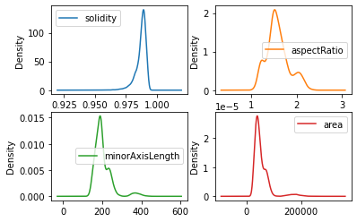

```python
# Density Plots
plt.rc('font', size =10)
data[myAtt].plot(kind='density', subplots=True, layout=(2,2), sharex=False)
plt.show()
```

```python
print(data[myAtt].head(20))
```

```
    solidity  aspectRatio  minorAxisLength    area
0   0.985226     1.792523       243.493533   82691
1   0.985645     1.636546       405.376992  208936
2   0.977934     1.613789       241.223210   73393
3   0.987497     2.059073       176.883982   50232
4   0.984140     1.506625       152.537045   27427
5   0.983637     2.104778       167.984051   45928
6   0.986301     1.475180       236.351649   64510
7   0.982387     1.891219       154.721078   35139
8   0.988639     1.519644       168.775658   33938
9   0.987228     2.089764       171.883678   48233
10  0.989636     1.060786       222.875023   41346
11  0.985356     1.603620       171.758805   37009
12  0.988935     1.678559       190.329895   47636
13  0.979531     1.635591       230.222014   67906
14  0.985861     1.591695       162.167935   32772
15  0.988816     2.040452       177.487271   50131
16  0.988577     1.417399       180.759200   36262
17  0.990926     1.120069       204.914629   36911
18  0.987812     1.440960       159.609367   28772
19  0.986696     1.596828       162.209963   32930
```

## Missing data & outliers

If there are less than 5% of missing data values, the best solution is to remove the cases from the dataset. However if it is a high number of cases of missing data, the best idea is to impute the values with the mean just to check the correlation with the other attributes, and then due to having such a high number of missing data cases, the whole attribute is not precise so it would finally be dumped from the dataset.

```python
print("Equal to zero")
print((data[myAtt] == 0).sum())
print()
print("Less than zero")
print((data[myAtt] < 0).sum())
print()
print("Standard deviation")
print(data[myAtt].std())
print()
print("Mean")
print(data[myAtt].mean())
```

```
Equal to zero
solidity           0
aspectRatio        0
minorAxisLength    0
area               0
dtype: int64

Less than zero
solidity           0
aspectRatio        0
minorAxisLength    0
area               0
dtype: int64

Standard deviation
solidity               0.004550
aspectRatio            0.247797
minorAxisLength       45.229734
area               29615.078522
dtype: float64

Mean
solidity               0.987142
aspectRatio            1.586112
minorAxisLength      202.543995
area               53303.710997
dtype: float64
```

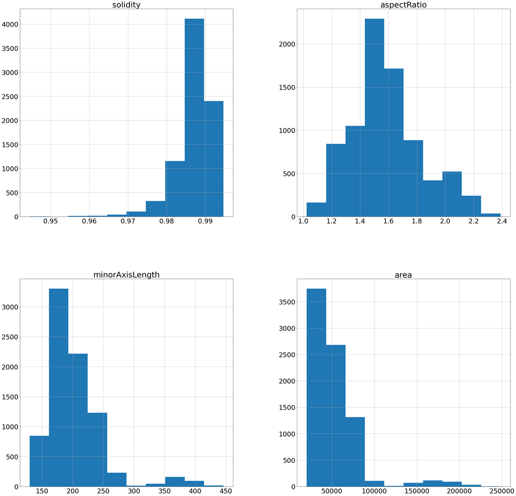

```python
plt.rc('font', size=30)
data[myAtt].hist(figsize=(40,40))
plt.show()
```

```
Attribute: SOLIDITY
Summary:
N outside of two STD:	 359 	( 4.4 %)
N outside of three STD:	 145 	( 1.78 %)
```

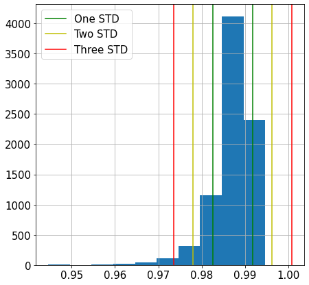

```
Attribute: ASPECTRATIO
Summary:
N outside of two STD:	 422 	( 5.17 %)
N outside of three STD:	 7 	( 0.09 %)
```

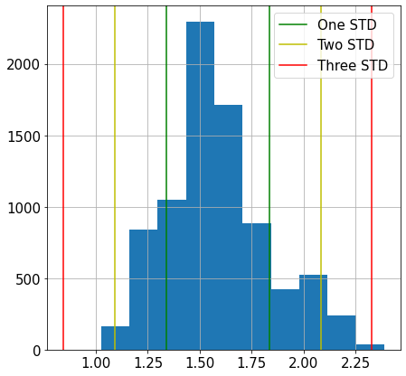

```
Attribute: MINORAXISLENGTH
Summary:
N outside of two STD:	 323 	( 3.96 %)
N outside of three STD:	 310 	( 3.8 %)
```

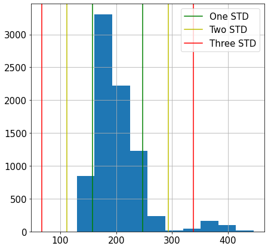

```
Attribute: AREA
Summary:
N outside of two STD:	 322 	( 3.94 %)
N outside of three STD:	 295 	( 3.61 %)
```

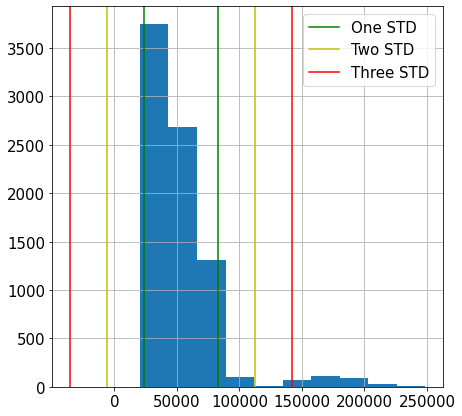

```python
def plotAttribute(featureName):
    plt.rc('font', size=15)
    oneSTD = data[featureName].std()
    twoSTD = oneSTD * 2
    threeSTD = oneSTD * 3
    meanValue = data[featureName].mean()

    print("Attribute:", featureName.upper())
    print("Summary:")

    instances = data.shape[0]
    outsideTwo = ((data[featureName] < (meanValue - twoSTD)).sum() + (data[featureName] > (meanValue + twoSTD)).sum())
    outsideThree = ((data[featureName] < (meanValue - threeSTD)).sum() + (data[featureName] > (meanValue + threeSTD)).sum())

    print("N outside of two STD:\t", outsideTwo, "\t(", round((outsideTwo/instances) *100, 2),"%)")
    print("N outside of three STD:\t", outsideThree, "\t(", round((outsideThree/instances) * 100, 2),"%)")

    plt.axvline(x=(meanValue - oneSTD), label='One STD', c="g")
    plt.axvline(x=(meanValue + oneSTD), c="g")

    plt.axvline(x=(meanValue - twoSTD), label='Two STD', c="y")
    plt.axvline(x=(meanValue + twoSTD), c="y")

    plt.axvline(x=(meanValue - threeSTD), label='Three STD', c="r")
    plt.axvline(x=(meanValue + threeSTD), c="r")

    data[featureName].hist(figsize=(7,7))
    plt.legend()
    plt.show()

for attribute in myAtt:
    plotAttribute(attribute)
```

## Missing Data

```python
print((data[myAtt] <= 0).sum())
missing = (data[myAtt] <= 0).sum()
total = len(data)
percentageMissing = round(((missing / total)*100),2)
print("-------------------------------------------")
print("Missing percentage :", percentageMissing,"%")
```

```
solidity           0
aspectRatio        0
minorAxisLength    0
area               0
dtype: int64
-------------------------------------------
Missing percentage : solidity           0.0
aspectRatio        0.0
minorAxisLength    0.0
area               0.0
dtype: float64 %
```

```python
# Class Counts
class_counts = data.groupby('class').size()
print(class_counts)
```

```
class
1    1213
2     808
3     318
4     989
5    1196
6    1564
7    2078
dtype: int64
```

## Question 2

Now that we have visualized the specific 4 attributes and made the necessary calculations, we can now identify the missing data and outliers.

- solidity: There is no missing data for this attribute as there are no negative values. However, we can see that there are 145 instances that fall outside of 3 STDs. Given the size of the dataset, these instances only account for 1.78%. Seen as this is lower than 5% of the population, we will remove these instances.
- aspectRatio: There is no missing data for this attribute as there are no negative values. However, there is a small number of instances (7) that fall outside of 3 STDs. Seen as these instances only take up 0.09% of the population, they will be removed.
- minorAxisLength: There is no missing data for this attribute as there are no negative values. However, we can find that there are 310 instances outside of 3 STDs which make up for 3.8% of the population. Therfore, as it is less than 5% of the population, these instances will be removed.
- area: There is no missing data for this attribute as there are no negative values. However, there are 295 instances that are outside of 3 STDs which represents less than 5% of the population. Therefore, these instances will be removed.

## Question 3

As we mentioned in the previous question, we are going to be removing all the instances where the value of one or more of the 4 attributes fall outside of 3 STDs. We can do this in a single marking and cleaning of data.

#### Marking the data

```python
for att in myAtt:
    meanValue = data[att].mean()
    threeSTD = 3*(data[att].std())
    data[att] = data[att].mask(data[att] < meanValue - threeSTD, np.NaN)
    data[att] = data[att].mask(data[att] > meanValue + threeSTD, np.NaN)

data[myAtt].isnull().sum()
```

[output not shown]

```
solidity           145
aspectRatio          7
minorAxisLength    310
area               295
dtype: int64
```

#### Cleaning and saving the data

```python
data.dropna(inplace=True)
data.to_csv('x00181490Q3.csv', header=False)
```

## Question 4

```python
##Make sure using cleaned data
data = pd.read_csv("x00181490Q3.csv", names = names)
```

#### Scatter plot for 4 specific attributes

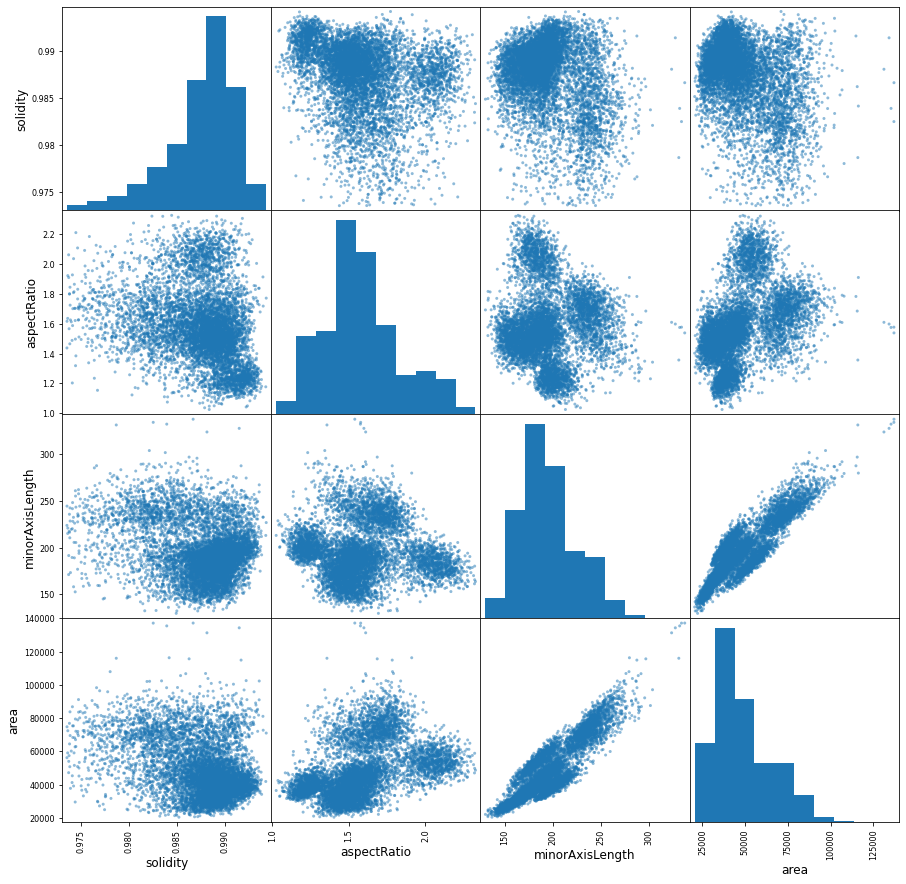

```python
# Scatter Plot
plt.rc('font', size =12)
pd.plotting.scatter_matrix(data[myAtt], figsize=(15,15))
plt.show()
```

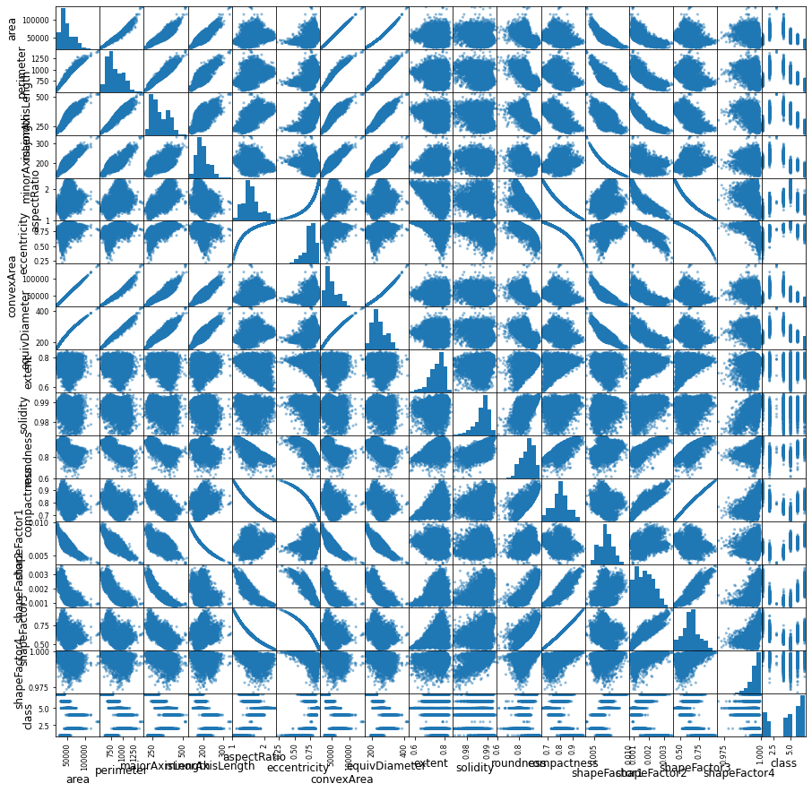

```python
# Scatter Plot
plt.rc('font', size =12)
pd.plotting.scatter_matrix(data, figsize=(15,15))
plt.show()
```

#### Correlation Table for 4 specific attributes

```python
print("Correlation Table")
corr = data[myAtt].corr()
corr.style.background_gradient().set_precision(2)
```

```
Correlation Table
```

|  | solidity | aspectRatio | minorAxisLength | area |
| --- | --- | --- | --- | --- |
| solidity | 1.00 | -0.27 | -0.26 | -0.37 |
| aspectRatio | -0.27 | 1.00 | -0.02 | 0.42 |
| minorAxisLength | -0.26 | -0.02 | 1.00 | 0.89 |
| area | -0.37 | 0.42 | 0.89 | 1.00 |

#### Correlation Table for all attributes

```python
print("Correlation Table")
corr = data.corr()
corr.style.background_gradient().set_precision(2)
```

```
Correlation Table
```

|  | area | perimeter | majorAxisLength | minorAxisLength | aspectRatio | eccentricity | convexArea | equivDiameter | extent | solidity | roundness | compactness | shapeFactor1 | shapeFactor2 | shapeFactor3 | shapeFactor4 | class |
| --- | --- | --- | --- | --- | --- | --- | --- | --- | --- | --- | --- | --- | --- | --- | --- | --- | --- |
| area | 1.00 | 0.98 | 0.93 | 0.89 | 0.42 | 0.41 | 1.00 | 1.00 | -0.07 | -0.37 | -0.61 | -0.43 | -0.85 | -0.74 | -0.43 | -0.46 | -0.39 |
| perimeter | 0.98 | 1.00 | 0.96 | 0.84 | 0.52 | 0.49 | 0.98 | 0.99 | -0.13 | -0.43 | -0.73 | -0.52 | -0.81 | -0.81 | -0.52 | -0.49 | -0.36 |
| majorAxisLength | 0.93 | 0.96 | 1.00 | 0.68 | 0.71 | 0.66 | 0.93 | 0.94 | -0.20 | -0.38 | -0.77 | -0.71 | -0.66 | -0.92 | -0.71 | -0.56 | -0.21 |
| minorAxisLength | 0.89 | 0.84 | 0.68 | 1.00 | -0.02 | -0.03 | 0.89 | 0.89 | 0.10 | -0.26 | -0.30 | 0.01 | -0.98 | -0.40 | 0.01 | -0.26 | -0.62 |
| aspectRatio | 0.42 | 0.52 | 0.71 | -0.02 | 1.00 | 0.92 | 0.42 | 0.43 | -0.39 | -0.27 | -0.78 | -0.99 | 0.04 | -0.88 | -0.98 | -0.50 | 0.29 |
| eccentricity | 0.41 | 0.49 | 0.66 | -0.03 | 0.92 | 1.00 | 0.41 | 0.41 | -0.34 | -0.32 | -0.73 | -0.97 | 0.06 | -0.89 | -0.98 | -0.50 | 0.45 |
| convexArea | 1.00 | 0.98 | 0.93 | 0.89 | 0.42 | 0.41 | 1.00 | 1.00 | -0.07 | -0.38 | -0.61 | -0.43 | -0.85 | -0.74 | -0.43 | -0.47 | -0.39 |
| equivDiameter | 1.00 | 0.99 | 0.94 | 0.89 | 0.43 | 0.41 | 1.00 | 1.00 | -0.08 | -0.36 | -0.62 | -0.45 | -0.86 | -0.76 | -0.44 | -0.46 | -0.40 |
| extent | -0.07 | -0.13 | -0.20 | 0.10 | -0.39 | -0.34 | -0.07 | -0.08 | 1.00 | 0.18 | 0.35 | 0.37 | -0.10 | 0.29 | 0.37 | 0.17 | -0.13 |
| solidity | -0.37 | -0.43 | -0.38 | -0.26 | -0.27 | -0.32 | -0.38 | -0.36 | 0.18 | 1.00 | 0.62 | 0.31 | 0.20 | 0.38 | 0.31 | 0.59 | 0.03 |
| roundness | -0.61 | -0.73 | -0.77 | -0.30 | -0.78 | -0.73 | -0.61 | -0.62 | 0.35 | 0.62 | 1.00 | 0.78 | 0.27 | 0.83 | 0.78 | 0.48 | 0.01 |
| compactness | -0.43 | -0.52 | -0.71 | 0.01 | -0.99 | -0.97 | -0.43 | -0.45 | 0.37 | 0.31 | 0.78 | 1.00 | -0.03 | 0.90 | 1.00 | 0.53 | -0.35 |
| shapeFactor1 | -0.85 | -0.81 | -0.66 | -0.98 | 0.04 | 0.06 | -0.85 | -0.86 | -0.10 | 0.20 | 0.27 | -0.03 | 1.00 | 0.38 | -0.04 | 0.22 | 0.65 |
| shapeFactor2 | -0.74 | -0.81 | -0.92 | -0.40 | -0.88 | -0.89 | -0.74 | -0.76 | 0.29 | 0.38 | 0.83 | 0.90 | 0.38 | 1.00 | 0.90 | 0.57 | -0.09 |
| shapeFactor3 | -0.43 | -0.52 | -0.71 | 0.01 | -0.98 | -0.98 | -0.43 | -0.44 | 0.37 | 0.31 | 0.78 | 1.00 | -0.04 | 0.90 | 1.00 | 0.53 | -0.37 |
| shapeFactor4 | -0.46 | -0.49 | -0.56 | -0.26 | -0.50 | -0.50 | -0.47 | -0.46 | 0.17 | 0.59 | 0.48 | 0.53 | 0.22 | 0.57 | 0.53 | 1.00 | -0.09 |
| class | -0.39 | -0.36 | -0.21 | -0.62 | 0.29 | 0.45 | -0.39 | -0.40 | -0.13 | 0.03 | 0.01 | -0.35 | 0.65 | -0.09 | -0.37 | -0.09 | 1.00 |

When it comes to the 4 specific attributes we can see that there is a strong correlation between area and minorAxisLength which is to be expected as one can be used to calculate the other. However, it is interesting to note that in the scatter plots we can identify some clusters in the plots of aspectRatio with minorAxisLength and aspectRatio and area. Despite there being a high correlation between minorAxisLength and area, I would not include both of them in the set of multicollinear attributes. Therefore, I would choose solidity, aspectRatio and area.

There are many attributes with a strong correlation between them but most of them are because one could be used to calculate the other, like for example, perimeter and area. Therefore, the set I would choose would be formed by compactness, shapeFactor3 and shapeFactor2.

## Correlations

### Correlation (largest values)

```python
print(data[myAtt].corr())
```

[output not shown]

### Correlation with "class" attribute

```python
for col in names[:-1]:
    print(col,"\t", data[col].corr(data["class"]))
```

[output not shown]

## Question 5

#### Regression (largest values)

```python
array = data.values
# get seperated input and classifies, using a deep copy of a list
X = array[:,0:16]
Y = array[:,16]
test = feature_selection.SelectKBest(score_func=feature_selection.f_regression, k=4)
fit = test.fit(X, Y)
print()
# have to manually display as no function to do so available
for index, result in enumerate(fit.scores_):
    print("{0:10}".format(names[index]),"{0:10}".format(round(result,2)))
```

```
area          1384.38
perimeter     1183.79
majorAxisLength      340.4
minorAxisLength     4872.5
aspectRatio     691.93
eccentricity    1955.15
convexArea    1378.46
equivDiameter    1503.71
extent         136.81
solidity         7.97
roundness        1.13
compactness    1094.11
shapeFactor1    5670.06
shapeFactor2      57.95
shapeFactor3    1259.13
shapeFactor4      61.85
```

According to the output, we would select shapeFactor1, minorAxisLength and eccentricity.

```python
dataREG = data[['shapeFactor1', 'minorAxisLength', 'eccentricity', 'class']]
```

#### RFE (Recursive Feature Elimination)

```python
array = data.values

# get seperated input and classifies, using a deep copy of a list
X = array[:,0:15]
Y = array[:,16]

model = linear_model.LogisticRegression(solver='liblinear')
rfe = feature_selection.RFE(model, 3)
fit = rfe.fit(X, Y)

print("Num Features: %d" % fit.n_features_)
print("\n{0:<10}".format("Attribute"),"{0:<10}".format("Select?"), "{0:<10}".format("Rank"))
print("---------------------------------")

for index, result in enumerate(list(fit.ranking_)):
    print("{0:<10}".format(names[index]),"{0:<10}".format(fit.support_[index]),"{0:<10}".format(result))
```

```
Num Features: 3

Attribute  Select?    Rank
---------------------------------
area       0          4
perimeter  0          2
majorAxisLength 1          1
minorAxisLength 1          1
aspectRatio 0          5
eccentricity 0          11
convexArea 0          3
equivDiameter 1          1
extent     0          10
solidity   0          9
roundness  0          6
compactness 0          8
shapeFactor1 0          12
shapeFactor2 0          13
shapeFactor3 0          7
```

According to the output of RFE, we would select majorAxisLength, minorAxisLength and equivDiameter.

```python
dataRFE = data[['majorAxisLength', 'minorAxisLength', 'equivDiameter', 'class']]
```

## Question 6

```
Dataset using regression
Dataset using RFE
```

```
array([[<AxesSubplot:title={'center':'majorAxisLength'}>,
        <AxesSubplot:title={'center':'minorAxisLength'}>],
       [<AxesSubplot:title={'center':'equivDiameter'}>,
        <AxesSubplot:title={'center':'class'}>]], dtype=object)
```

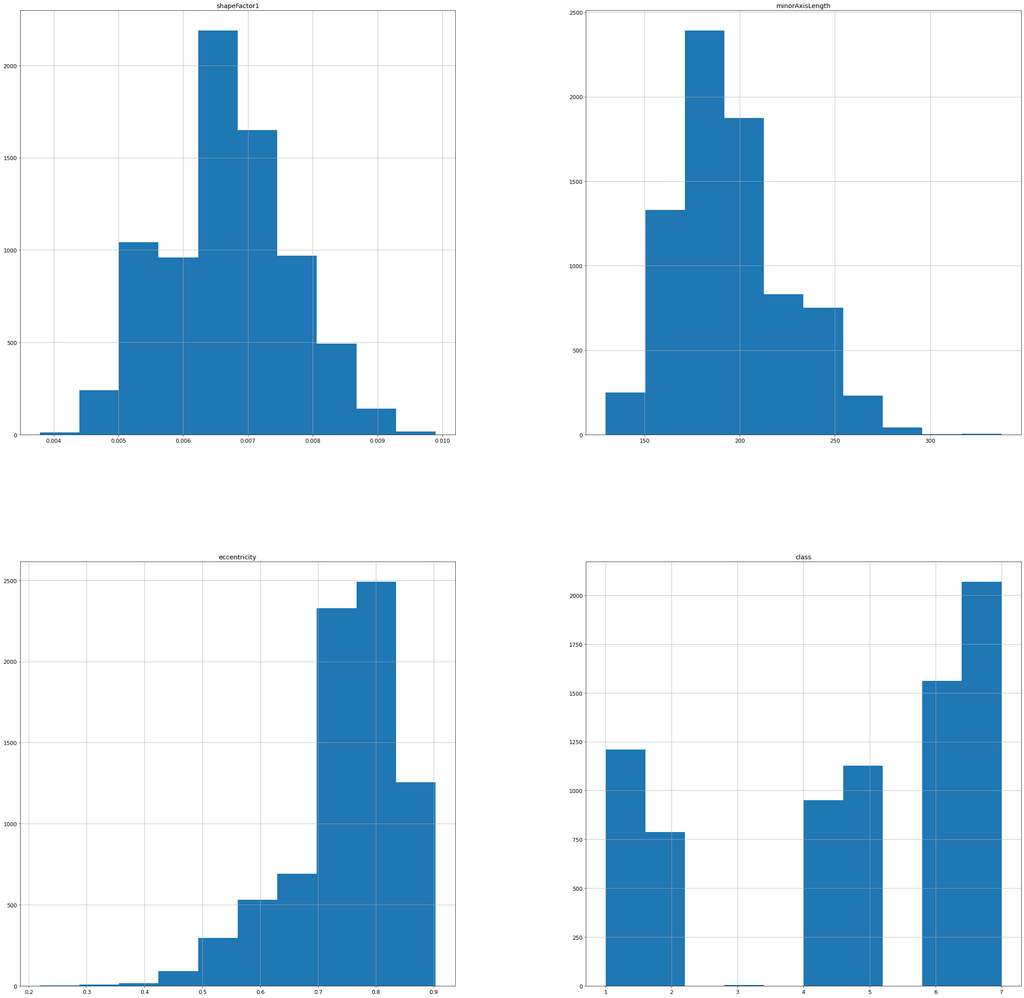

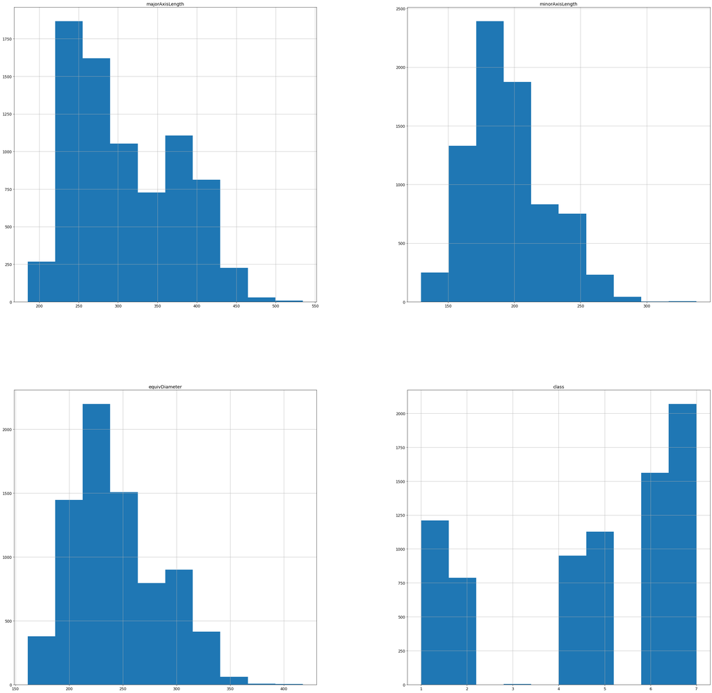

```python
print('Dataset using regression')
dataREG.hist(figsize=(40,40))

print('Dataset using RFE')
dataRFE.hist(figsize=(40,40))
```

For both datasets I will normalize the data because I don't believe that all the attributes follow a Gaussian distribution.

#### Normalize

```python
# Regression data
array = dataREG.values
X = array[:,0:3]
Y = array[:,3]
scaler = preprocessing.Normalizer().fit(X)
normalizedX = scaler.transform(X)
normalizedX = pd.DataFrame(normalizedX)
print(normalizedX)
Y = pd.DataFrame(Y)
print(Y)
outData = pd.concat([normalizedX, Y], axis=1, sort=False)
outData.to_csv("X00181490Q7a.csv", header = False, index = False)

# RFE data
array = dataRFE.values
X = array[:,0:3]
Y = array[:,3]
scaler = preprocessing.Normalizer().fit(X)
normalizedX = scaler.transform(X)
normalizedX = pd.DataFrame(normalizedX)
Y = pd.DataFrame(Y)
outData = pd.concat([normalizedX, Y], axis=1, sort=False)
outData.to_csv("X00181490Q7b.csv", header = False, index = False)
```

```
             0         1         2
0     0.000022  0.999994  0.003408
1     0.000022  0.999995  0.003254
2     0.000041  0.999988  0.004942
3     0.000055  0.999988  0.004903
4     0.000046  0.999986  0.005238
...        ...       ...       ...
7705  0.000042  0.999991  0.004351
7706  0.000026  0.999993  0.003741
7707  0.000046  0.999990  0.004579
7708  0.000024  0.999993  0.003616
7709  0.000039  0.999988  0.004853

[7710 rows x 3 columns]
        0
0     4.0
1     2.0
2     5.0
3     7.0
4     5.0
...   ...
7705  7.0
7706  4.0
7707  6.0
7708  4.0
7709  5.0

[7710 rows x 1 columns]
```